# Assignment_5

Felix Froschauer

29 12 2021

## General Setup

First of all, we need to import all necessary libraries and set up the working directory correctly.

```r
library(httr)
library(jsonlite)
library(ggplot2)
library(readr)
library(dplyr)
```

## Exercise 1 - Setting up a new GitHub repository

The whole assignment can be accessed publicly using the following link: https://github.com/froschauerfelix/dspm_5

## Exercise 2 - Getting to know the API

When you are sharing your code, the personalized API-Key should stay hidden. To achieve that, the API-Key can be imported using another file and only in that specific file, the API-Key can be detected. Having the API-Key imported into our file, it can be used to send the first get-requests.

```r
source("~/R/DS ProjectManagement/Assignment 5/API_key.R")
```

## Exercise 3 - Interacting with the API - the basics

After sending the first request, the status of the response needs to be reviewed. Here: The status is 200. Everything is working fine.

```
## Response [https://app.ticketmaster.com/discovery/v2/venues.json?countryCode=DE&apikey=7elxdku9GGG5k8j0Xm8KWdANDgecHMV0&locale=*]
##   Date: 2021-12-29 15:59
##   Status: 200
##   Content-Type: application/json;charset=utf-8
##   Size: 12 kB
```

A single get-request leads to a data set with 20 different venues. Only the first page is accessed here and to access more data, more requests need to be send.

```
## Rows: 20
## Columns: 7
## $ name       <chr> "Gruenspan", "Philharmonie (Großer Saal)", "Beatpol", "Mart~
## $ city       <chr> "Hamburg", "Berlin", "Dresden", "Dresden", "Dessau-Roßlau",~
## $ postalcode <chr> "22767", "10785", "01157", "01099", "06844", "80809", NA, "~
## $ address    <chr> "Grosse Freiheit 58", "Herbert-von-Karajan-Straße 1", "Altb~
## $ url        <chr> "http://www.ticketmaster.de/venue/287155", "https://www.tic~
## $ long       <chr> "9.958075", "13.36896", "13.67471", "13.7566", "12.24645", ~
## $ lat        <chr> "53.551885", "52.51007", "51.06498", "51.06435", "51.83364"~
```

## Exercise 4 - Interacting with the API - advanced

Iterating through all pages takes time. For that reason, I have saved all venues in Germany in a .csv file and the iteration doesn’t need to be executed for each separate working session. The data can be updated in a separate file, so that it’s always up to date. The code can be viewed in the [github repository](https://github.com/froschauerfelix/dspm_5) in the file `get_all_data.R`.

```
## Rows: 12,560
## Columns: 8
## $ ...1       <dbl> 1, 2, 3, 4, 5, 6, 7, 8, 9, 10, 11, 12, 13, 14, 15, 16, 17, ~
## $ name       <chr> "Gruenspan", "Philharmonie (Gro\xdfer Saal)", "Beatpol", "M~
## $ city       <chr> "Hamburg", "Berlin", "Dresden", "Dresden", "Dessau-Ro\xdfla~
## $ postalcode <chr> "22767", "10785", "01157", "01099", "06844", "80809", NA, "~
## $ address    <chr> "Grosse Freiheit 58", "Herbert-von-Karajan-Stra\xdfe 1", "A~
## $ url        <chr> "http://www.ticketmaster.de/venue/287155", "https://www.tic~
## $ long       <dbl> 9.958075, 13.368960, 13.674710, 13.756600, 12.246450, 11.55~
## $ lat        <dbl> 53.55188, 52.51007, 51.06498, 51.06435, 51.83364, 48.17543,~
```

# Exercise 5 - Visualizing the extracted data

Not every venue location can be plotted. Wrong latitude and longitude values need to be filtered and missing values (for long and lat) need to be excluded. Out of the 12560 observations about 8099 are plotted here (last updated: 29. December).

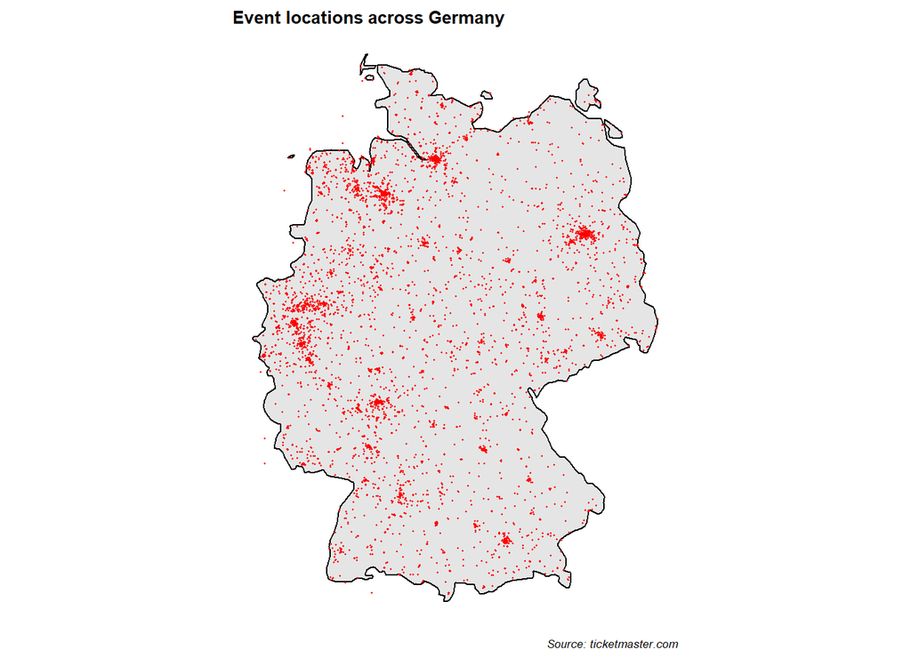

## Exercise 6 - Event locations in France

Exercises 2 to 5 are repeated here for another country: France.

First page observations:

```
## Rows: 20
## Columns: 7
## $ name       <chr> "Stade Pierre-Mauroy", "Le Trabendo", "Stade Chaban-Delmas ~
## $ city       <chr> "Villeneuve-d'Ascq", "Paris", "Bordeaux", "Paris", "Madelei~
## $ postalcode <chr> "59650", "75019", "33000", "75012", "62170", "06500", "7501~
## $ address    <chr> "261 Boulevard de Tournai", "Parc de la Villette, 211 Avenu~
## $ url        <chr> "https://www.ticketmaster.be/venue/stade-pierre-mauroy-vill~
## $ long       <chr> "3.1305", "2.39026", NA, "2.378568", "1.75239", "7.527968",~
## $ lat        <chr> "50.61191", "48.8938489", NA, "48.838721", "50.470086", "43~
```

For all pages:

```
## Rows: 19,400
## Columns: 8
## $ ...1       <dbl> 1, 2, 3, 4, 5, 6, 7, 8, 9, 10, 11, 12, 13, 14, 15, 16, 17, ~
## $ name       <chr> "Stade Pierre-Mauroy", "Le Trabendo", "Stade Chaban-Delmas"~
## $ city       <chr> "Villeneuve-d'Ascq", "Paris", "Bordeaux", "Paris", "Madelei~
## $ postalcode <chr> "59650", "75019", "33000", "75012", "62170", "06500", "7501~
## $ address    <chr> "261 Boulevard de Tournai", "Parc de la Villette, 211 Avenu~
## $ url        <chr> "https://www.ticketmaster.be/venue/stade-pierre-mauroy-vill~
## $ long       <dbl> 3.130500, 2.390260, NA, 2.378568, 1.752390, 7.527968, 2.371~
## $ lat        <dbl> 50.61191, 48.89385, NA, 48.83872, 50.47009, 43.78589, 48.86~
```

Exluding the extreme values for France, the following plot can be drawn.

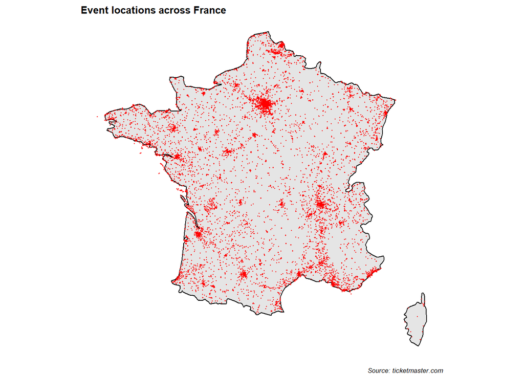